# King County Housing Data

Alan Arnholt

April 19, 2016

Reading the comma separated file from the `Data` directory one level up from where this document is stored using the `read.csv()` function. Variable descriptions were obtained from [King County, Department of Assessments](http://your.kingcounty.gov/assessor/eRealProperty/ResGlossaryOfTerms.html). All feature engineering should be done in one the first code chunks of your document.

```r
housedata <- read.csv("../Data/housedata.csv",
                      colClasses = c(id = "character", date = "character",
                                     yr_built = "character", zipcode = "factor", grade = "factor"))
housedata$date <- as.Date(housedata$date, "%Y%m%d")
housedata$waterfront <- factor(housedata$waterfront, labels = c("No", "Yes"))
housedata$condition <- factor(housedata$condition, labels = c("poor", "fair", "average", "good", "very good"))
housedata$yr_renovated <- ifelse(housedata$yr_renovated == 0, housedata$yr_built, housedata$yr_renovated)
housedata$yr_built <- as.Date(ISOdate(housedata$yr_built, 9, 1))  # Complete Year, Sept 1
housedata$yr_renovated <- as.Date(ISOdate(housedata$yr_renovated, 9, 1))  # Last renovated Year, Sept 1
housedata <- housedata[, -1]
#### Perform same steps with test set
housedataT <- read.csv("../Data/housedataTEST.csv",
                      colClasses = c(id = "character", date = "character",
                                     yr_built = "character", zipcode = "factor", grade = "factor"))
housedataT$date <- as.Date(housedataT$date, "%Y%m%d")
housedataT$waterfront <- factor(housedataT$waterfront, labels = c("No", "Yes"))
housedataT$condition <- factor(housedataT$condition, labels = c("poor", "fair", "average", "good", "very good"))
housedataT$yr_renovated <- ifelse(housedataT$yr_renovated == 0, housedataT$yr_built, housedataT$yr_renovated)
housedataT$yr_built <- as.Date(ISOdate(housedataT$yr_built, 9, 1))  # Complete Year, Sept 1
housedataT$yr_renovated <- as.Date(ISOdate(housedataT$yr_renovated, 9, 1))  # Last renovated Year, Sept 1
housedataT <- housedataT[, -1]
```

```r
library(DT)
datatable(housedata[, 2:10], rownames = FALSE)
```

| price | bedrooms | bathrooms | sqft_living | sqft_lot | floors | waterfront | view | condition |
| --- | --- | --- | --- | --- | --- | --- | --- | --- |
| 221900 | 3 | 1 | 1180 | 5650 | 1 | No | 0 | average |
| 538000 | 3 | 2.25 | 2570 | 7242 | 2 | No | 0 | average |
| 180000 | 2 | 1 | 770 | 10000 | 1 | No | 0 | average |
| 604000 | 4 | 3 | 1960 | 5000 | 1 | No | 0 | very good |
| 510000 | 3 | 2 | 1680 | 8080 | 1 | No | 0 | average |
| 1225000 | 4 | 4.5 | 5420 | 101930 | 1 | No | 0 | average |
| 257500 | 3 | 2.25 | 1715 | 6819 | 2 | No | 0 | average |
| 291850 | 3 | 1.5 | 1060 | 9711 | 1 | No | 0 | average |
| 229500 | 3 | 1 | 1780 | 7470 | 1 | No | 0 | average |
| 323000 | 3 | 2.5 | 1890 | 6560 | 2 | No | 0 | average |

[output cut: 17374 more lines]

Consider predicting the price (`price`) of a house based on a certain feature (`sqft_living`). Start by graphing the relationship.

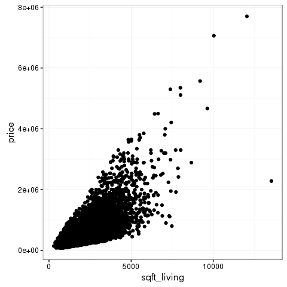

```r
library(ggplot2)
p1 <- ggplot(data = housedata, aes(x = sqft_living, y = price)) +
  geom_point() +
  theme_bw()
p1
```

Overplotting is problematic. What should we do?

- Consider making the plotting shape smaller.
- Make the points semitransparent (`alpha`).
- Bin the data into rectangles.
- Bin the data into hexagons.

### Using `alpha`

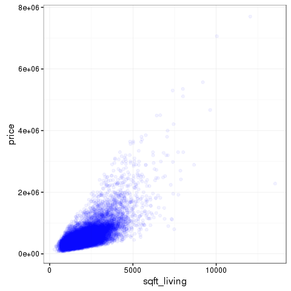

```r
p2 <- ggplot(data = housedata, aes(x = sqft_living, y = price)) +
        geom_point(alpha = 0.05, color = "blue") +
        theme_bw()
p2
```

### Using rectangles

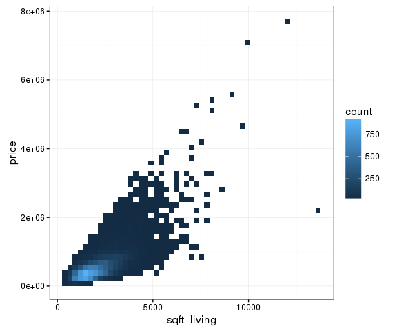

```r
p3 <- ggplot(data = housedata, aes(x = sqft_living, y = price)) +
        stat_bin2d(bins = 50) +
        theme_bw()
p3
```

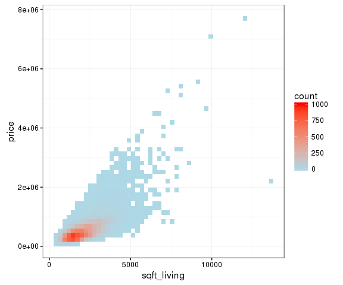

```r
p4 <- ggplot(data = housedata, aes(x = sqft_living, y = price)) +
        stat_bin2d(bins = 50) +
        scale_fill_gradient(low = "lightblue", high = "red",
                            limits = c(0, 1000)) +
        theme_bw()
p4
```

### Using hexagons

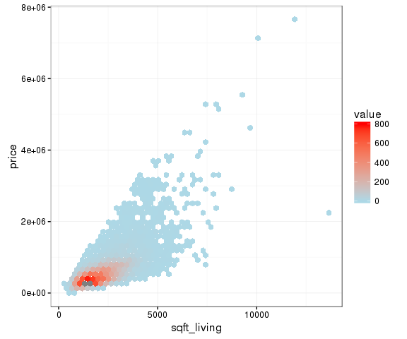

```r
p5 <- ggplot(data = housedata, aes(x = sqft_living, y = price)) +
        stat_binhex(bins = 50) +
        scale_fill_gradient(low = "lightblue", high = "red",
                            limits = c(0, 800), breaks = seq(0, 800, by = 200)) +
        theme_bw()
p5
```

**Note* For both `stat_bin2d` and `stat_binhex`, if you manually specify the range, and there is a bin that falls outside that range because it has too many of too few points, that bin will show up as grey rather than the color at the high or low end of the range. Observe the gray hexagons in the lower left corner of the above graph.

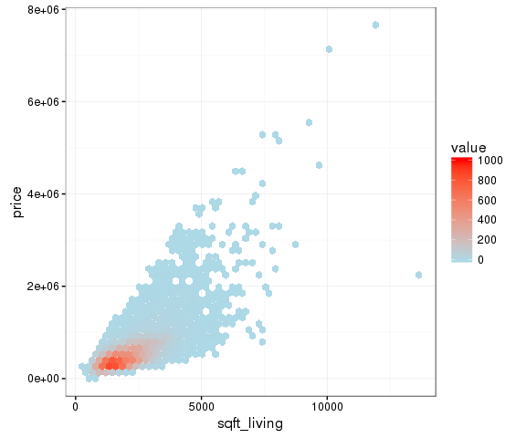

```r
p6 <- ggplot(data = housedata, aes(x = sqft_living, y = price)) +
        stat_binhex(bins = 50) +
        scale_fill_gradient(low = "lightblue", high = "red",
                            limits = c(0, 1000), breaks = seq(0, 1000, by = 200)) +
        theme_bw()
p6
```

## What features might be visible in a scatterplot?

- Causal relationships (linear and nonlinear) - One variable may have a direct influence on another in some way.
- Associations - Variables may be associated with on another without being directly causally related.
- Outliers of groups of outliers - Cases can be outliers in two dimensions without being outliers in either dimension separately.
- Clusters - Sometimes there are groups of cases which are separate from the rest of the data.
- Gaps - Occasionally, particular combinations of values do not occur.
- Barriers - Some combinations of values may not be possible
- Conditional relationship - Sometimes the relationship between two variables is better summarized by a conditional description that by a function.

Use a simple linear model to predict the price of a house with 2,500 $\text{ft}^2$.

```r
slm <- lm(price ~ sqft_living, data = housedata)
summary(slm)
```

```
Call:
lm(formula = price ~ sqft_living, data = housedata)

Residuals:
     Min       1Q   Median       3Q      Max
-1490607  -148265   -23758   105710  4349512

Coefficients:
              Estimate Std. Error t value Pr(>|t|)
(Intercept) -47116.079   4923.344   -9.57   <2e-16 ***
sqft_living    281.959      2.164  130.29   <2e-16 ***
---
Signif. codes:  0 '***' 0.001 '**' 0.01 '*' 0.05 '.' 0.1 ' ' 1

Residual standard error: 263000 on 17382 degrees of freedom
Multiple R-squared:  0.4941,    Adjusted R-squared:  0.4941
F-statistic: 1.698e+04 on 1 and 17382 DF,  p-value: < 2.2e-16
```

```r
predict(slm, newdata = data.frame(sqft_living = 2500))
```

```
     1
657781
```

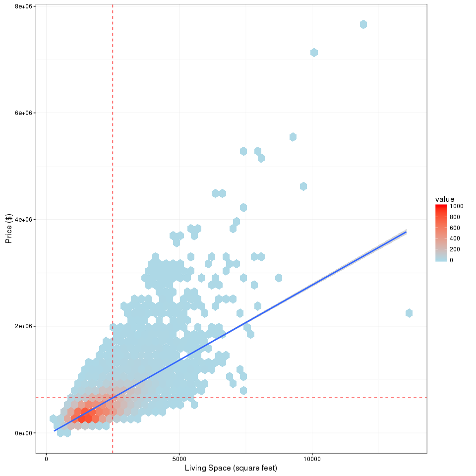

```r
p6 + geom_smooth(method = "lm") +
  geom_vline(xintercept = 2500,linetype = "dashed", color = "red") +
  geom_hline(yintercept = predict(slm, newdata = data.frame(sqft_living = 2500)), linetype = "dashed", color = "red") +
  labs(x = "Living Space (square feet)", y = "Price ($)")
```

`mod.zip` most basic model.

```r
mod.zip <- lm(price ~ 1, data = housedata)
summary(mod.zip)
```

```
Call:
lm(formula = price ~ 1, data = housedata)

Residuals:
    Min      1Q  Median      3Q     Max
-464367 -219367  -89367  100633 7160633

Coefficients:
            Estimate Std. Error t value Pr(>|t|)
(Intercept)   539367       2804   192.4   <2e-16 ***
---
Signif. codes:  0 '***' 0.001 '**' 0.01 '*' 0.05 '.' 0.1 ' ' 1

Residual standard error: 369700 on 17383 degrees of freedom
```

`mod.all` all current features except `sqft_basement`.

```r
mod.all <- lm(price ~ . - sqft_basement, data = housedata)
summary(mod.all)
```

```
Call:
lm(formula = price ~ . - sqft_basement, data = housedata)

Residuals:
     Min       1Q   Median       3Q      Max
-1539648   -60120     2700    56110  3478116

Coefficients:
                     Estimate Std. Error t value Pr(>|t|)
(Intercept)        -4.135e+07  6.410e+06  -6.450 1.15e-10 ***
date                1.145e+02  1.016e+01  11.269  < 2e-16 ***
bedrooms           -1.431e+04  1.708e+03  -8.377  < 2e-16 ***
bathrooms           2.394e+04  2.764e+03   8.663  < 2e-16 ***
sqft_living         1.170e+02  3.714e+00  31.495  < 2e-16 ***
sqft_lot            2.574e-01  4.059e-02   6.342 2.32e-10 ***
floors             -2.963e+04  3.344e+03  -8.862  < 2e-16 ***
waterfrontYes       6.641e+05  1.465e+04  45.331  < 2e-16 ***
view                4.953e+04  1.828e+03  27.102  < 2e-16 ***
conditionfair       9.809e+04  3.414e+04   2.873 0.004075 **
conditionaverage    1.042e+05  3.174e+04   3.282 0.001032 **
conditiongood       1.318e+05  3.175e+04   4.151 3.32e-05 ***
conditionvery good  1.814e+05  3.194e+04   5.677 1.39e-08 ***
grade10             1.173e+05  1.549e+05   0.757 0.448960
grade11             3.143e+05  1.552e+05   2.025 0.042869 *
grade12             7.525e+05  1.561e+05   4.821 1.44e-06 ***
grade13             1.661e+06  1.615e+05  10.287  < 2e-16 ***
grade3             -7.935e+02  1.776e+05  -0.004 0.996434
grade4             -9.356e+04  1.588e+05  -0.589 0.555737
grade5             -1.035e+05  1.548e+05  -0.668 0.503898
grade6             -1.122e+05  1.547e+05  -0.725 0.468200
grade7             -1.091e+05  1.547e+05  -0.705 0.480711
grade8             -8.819e+04  1.548e+05  -0.570 0.568766
grade9             -1.235e+04  1.548e+05  -0.080 0.936432
sqft_above          5.176e+01  3.858e+00  13.416  < 2e-16 ***
yr_built           -3.312e+00  2.798e-01 -11.838  < 2e-16 ***
yr_renovated        2.591e+00  2.847e-01   9.103  < 2e-16 ***
zipcode98002        1.909e+04  1.516e+04   1.259 0.207972
zipcode98003       -1.207e+04  1.341e+04  -0.900 0.368288
zipcode98004        7.176e+05  2.455e+04  29.229  < 2e-16 ***
zipcode98005        2.534e+05  2.626e+04   9.650  < 2e-16 ***
```

[output cut: 60 more lines]

```
zipcode98177        1.079e+05  3.190e+04   3.382 0.000720 ***
zipcode98178       -5.908e+03  1.861e+04  -0.317 0.750888
zipcode98188       -4.184e+03  1.898e+04  -0.220 0.825497
zipcode98198       -3.087e+04  1.448e+04  -2.132 0.033009 *
zipcode98199        2.724e+05  2.639e+04  10.323  < 2e-16 ***
lat                 2.233e+05  6.632e+04   3.367 0.000761 ***
long               -2.361e+05  4.727e+04  -4.995 5.95e-07 ***
sqft_living15       1.521e+01  3.029e+00   5.023 5.15e-07 ***
sqft_lot15         -1.159e-01  6.429e-02  -1.803 0.071344 .
---
Signif. codes:  0 '***' 0.001 '**' 0.01 '*' 0.05 '.' 0.1 ' ' 1

Residual standard error: 150200 on 17284 degrees of freedom
Multiple R-squared:  0.8359,    Adjusted R-squared:  0.835
F-statistic: 889.4 on 99 and 17284 DF,  p-value: < 2.2e-16
```

Your goal is to create a model with as small a test error as possible. Note that the square root of the training RSS from model `mod.all` is $1.5018076\times 10^{5}$.

[figure not shown]

```r
library(ggmap)
KingMap <-
  get_map(
    location = c(lon = -122.1, lat = 47.48),
    zoom = 10,
    source = "google",
    maptype = "roadmap"
  )
ggmap(KingMap) +
  geom_point(
    aes(x = housedata$long, y = housedata$lat),
    data = housedata,
    alpha = .2,
    color = "blue",
    size = 0.01
  ) +
  geom_point(
    aes(x = housedataT$long, y = housedataT$lat),
    data = housedataT,
    alpha = .2,
    color = "red",
    size = 0.01
  ) +
  ggtitle("Houses Sold in King County, Wa (2014-2015)") +
  labs(x = "longitute", y = "latitude")
```

## Prediction

- Submit a vector named (`yourlastname_yourfirstname`) with the predicted house prices for your model using the data frame `housedataT`.
- Suppose your final model is `mod.all`.

```r
yourlastname_yourfirstname <- predict(mod.all, newdata = housedataT)
head(yourlastname_yourfirstname)
```

```
       1        2        3        4        5        6
310196.9 845551.2 305946.0 532806.5 485256.6 469122.8
```

I will compute your $\sqrt{MSPE}$.

```r
SMSPE <- sqrt(mean((head(yourlastname_yourfirstname) - c(310000, 650000, 233000, 580500, 535000, 605000))^2))
SMSPE
```

```
[1] 105493.4
```